# Differences in self-similarity by wallpaper group

Rick Gilmore

2021-06-30 15:02:52

# Purpose

This document summarizes Rick Gilmore’s analysis of participant sorting data.

# Analysis plan

1. Did the wallpaper groups differ in terms of the *number of sets* into which exemplars were sorted? For example, Vedak et al., 2015 suggested that P1 exemplars were sorted into fewer sets.
2. Were there differences in mean *Jaccard indices* by wallpaper group?
3. Are there wallpaper groups with exemplar pairs that have especially high Jaccard indices?

# Import data

## N sets

The N sets data are found in `analysis/data/nsets.csv`.

```r
nsets <- readr::read_csv("analysis/data/nsets.csv")
```

## Jaccard indices

The Jaccard index data are found in `analysis/data/jaccard.csv`.

```r
jaccard <- readr::read_csv("analysis/data/jaccard.csv")
```

# N sets data

## Visualizations

### N exemplars per set

Let’s view the number of exemplars per set per participant. That is, each dot in the plot below is one set contributed by one participant.

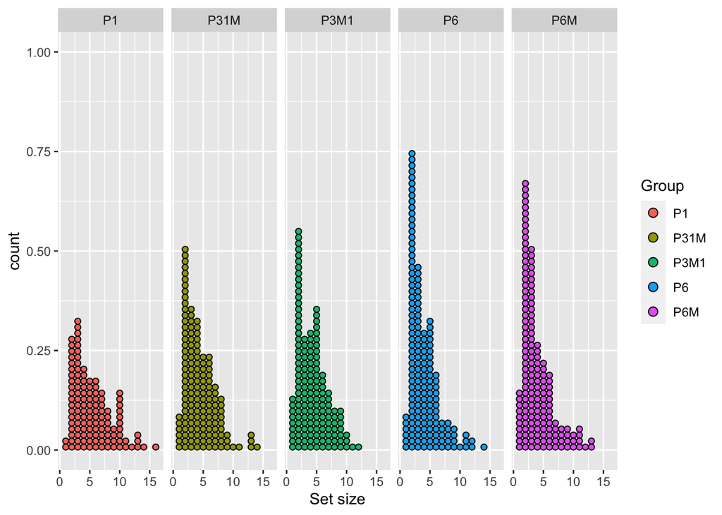

```r
exemplars_per_set_plot <- nsets %>%
  ggplot(.) +
  aes(x = Nsets, fill = Group) +
  geom_dotplot(method="histodot", dotsize = 1, binwidth = 1) +
  facet_grid(. ~ Group ) +
  xlab("Set size")
exemplars_per_set_plot
```

### N sets/participant and group

We can also calculate the number of sets per participant and wallpaper group.

```r
nsets_participant <- nsets %>%
  dplyr::group_by(., Participant, Group) %>%
  dplyr::summarise(., nsets_per = n())
```

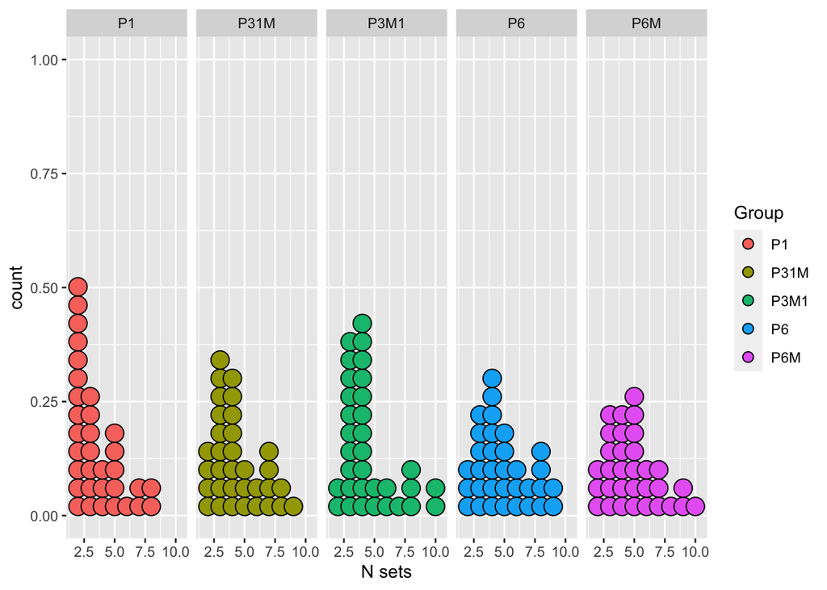

```r
nsets_participant_plot <- nsets_participant %>%
  ggplot(.) +
  aes(x = nsets_per, fill = Group) +
  geom_dotplot(method="histodot", dotsize = 1.5, binwidth = 1) +
  facet_grid(. ~ Group ) +
  xlab("N sets")
nsets_participant_plot
```

## Analyses

### N exemplars

```r
n_exemplars_mod1 <- afex::aov_car(Nsets ~ Group + Error(Participant/Group), data = nsets)
summary(n_exemplars_mod1)
```

```
##
## Univariate Type III Repeated-Measures ANOVA Assuming Sphericity
##
##             Sum Sq num Df Error SS den Df F value
## (Intercept) 4651.9      1   590.27     31 244.309
## Group         88.4      4   266.25    124  10.297
##                Pr(>F)
## (Intercept) 2.992e-16 ***
## Group       3.118e-07 ***
## ---
## Signif. codes:
## 0 '***' 0.001 '**' 0.01 '*' 0.05 '.' 0.1 ' ' 1
##
##
## Mauchly Tests for Sphericity
##
##       Test statistic   p-value
## Group        0.33194 0.0001712
##
##
## Greenhouse-Geisser and Huynh-Feldt Corrections
##  for Departure from Sphericity
##
##        GG eps Pr(>F[GG])
## Group 0.65361  2.089e-05 ***
## ---
## Signif. codes:
## 0 '***' 0.001 '**' 0.01 '*' 0.05 '.' 0.1 ' ' 1
##
##          HF eps   Pr(>F[HF])
## Group 0.7192192 9.377343e-06
```

P1 exemplars were sorted into larger sets than other wallpaper groups.

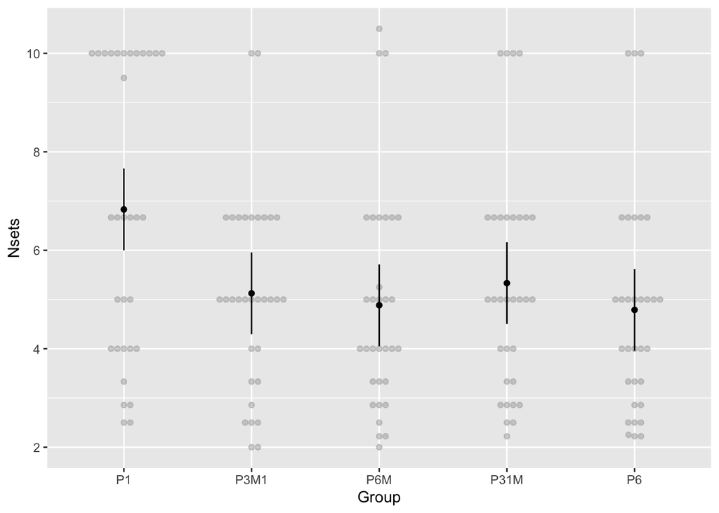

```r
afex::afex_plot(n_exemplars_mod1, x = "Group", y = "Nsets")
```

### Set sizes

```r
set_size_mod1 <- afex::aov_car(nsets_per ~ Group + Error(Participant/Group), data = nsets_participant)
summary(set_size_mod1)
```

```
##
## Univariate Type III Repeated-Measures ANOVA Assuming Sphericity
##
##             Sum Sq num Df Error SS den Df  F value
## (Intercept) 3303.3      1   491.69     31 208.2648
## Group         37.1      4   156.90    124   7.3301
##                Pr(>F)
## (Intercept) 2.657e-15 ***
## Group       2.478e-05 ***
## ---
## Signif. codes:
## 0 '***' 0.001 '**' 0.01 '*' 0.05 '.' 0.1 ' ' 1
##
##
## Mauchly Tests for Sphericity
##
##       Test statistic   p-value
## Group        0.41627 0.0022527
##
##
## Greenhouse-Geisser and Huynh-Feldt Corrections
##  for Departure from Sphericity
##
##        GG eps Pr(>F[GG])
## Group 0.71834  0.0002361 ***
## ---
## Signif. codes:
## 0 '***' 0.001 '**' 0.01 '*' 0.05 '.' 0.1 ' ' 1
##
##          HF eps Pr(>F[HF])
## Group 0.7994868 0.00012293
```

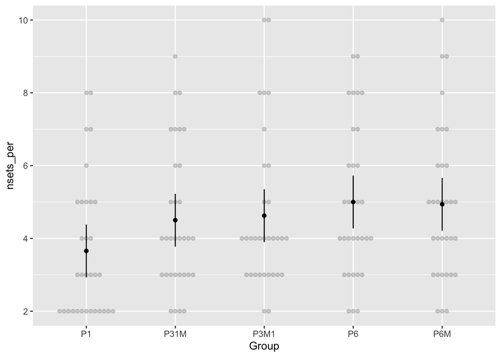

```r
afex::afex_plot(set_size_mod1, x = "Group", y = "Nsets")
```

Participants sorted P1 exemplars into a smaller number of categories than the other wallpaper groups.

# Jaccard index data

## Visualizations

[output not shown]

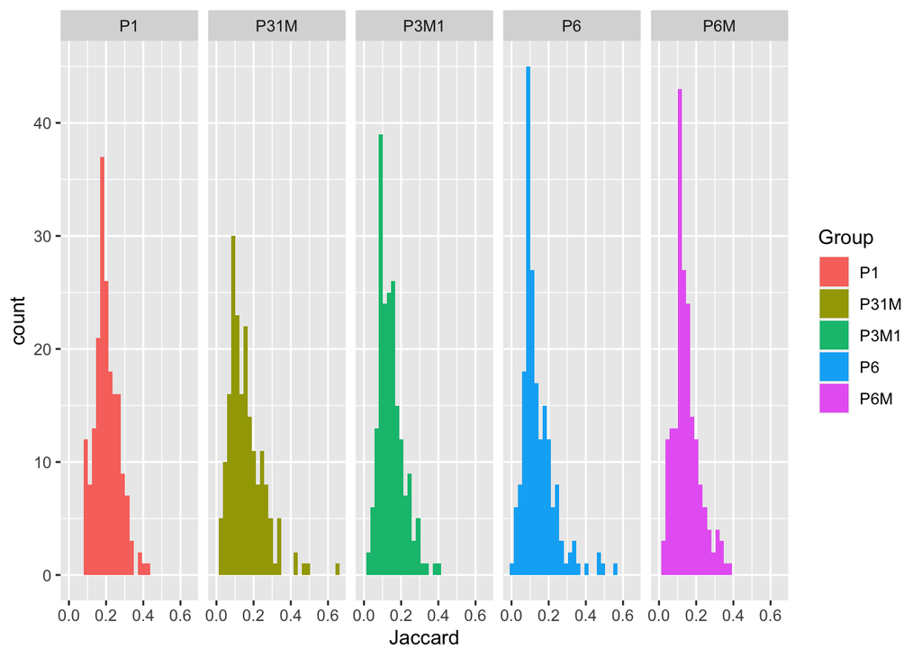

```r
jaccard_plot_1 <- jaccard %>%
  ggplot(.) +
  aes(x = Jaccard, fill = Group) +
  geom_histogram() +
  facet_grid(. ~ Group)
jaccard_plot_1
```

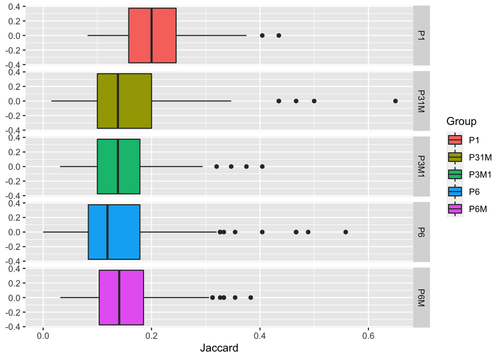

```r
jaccard_plot_2 <- jaccard %>%
  ggplot(.) +
  aes(x = Jaccard, fill = Group) +
  geom_boxplot() +
  facet_grid(Group ~ .)
jaccard_plot_2
```

The mean Jaccard similarity indices across the exemplars was higher for P1; however, note the outliers.

### Jaccard outliers

It may be useful to examine those exemplar pairs that have especially large Jaccard indices.

As a starting point for exploration, we examine those exemplars with Jaccard indices > some threshold. Here, we choose 0.35.

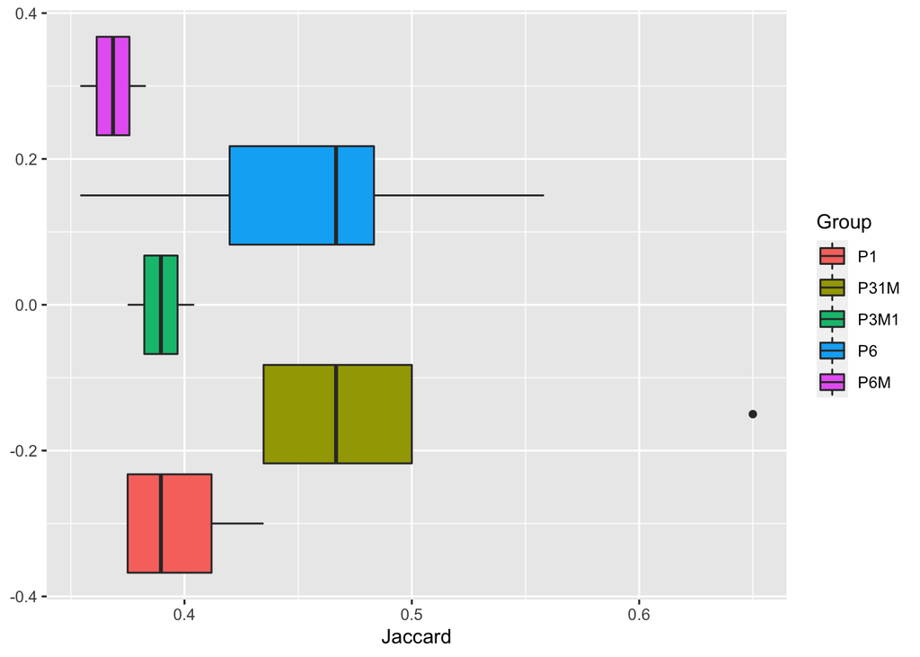

```r
jaccard_plot_4 <- jaccard %>%
  filter(., Jaccard > j_thresh) %>%
  ggplot(.) +
  aes(x = Jaccard, fill = Group) +
  geom_boxplot()
jaccard_plot_4
```

So, P6 and P31M have a few highly similar exemplar pairs:

```r
jaccard %>%
  filter(., Jaccard > .35) %>%
  arrange(., Group, Exemplar.Row)
```

```
## # A tibble: 19 x 4
##    Exemplar.Row Exemplar.Col Jaccard Group
##           <dbl>        <dbl>   <dbl> <chr>
##  1            7           19   0.375 P1
##  2            8            9   0.435 P1
##  3           10           16   0.404 P1
##  4           16           20   0.375 P1
##  5            2            7   0.65  P31M
##  6            2           14   0.435 P31M
##  7            2           20   0.435 P31M
##  8            4            9   0.467 P31M
##  9           14           20   0.5   P31M
## 10           11           19   0.375 P3M1
## 11           19           20   0.404 P3M1
## 12            2           11   0.404 P6
## 13            6           13   0.558 P6
## 14            6           19   0.467 P6
## 15            7            9   0.467 P6
## 16            8            9   0.354 P6
## 17           13           19   0.489 P6
## 18            8           20   0.354 P6M
## 19           10           20   0.383 P6M
```

#### P31M

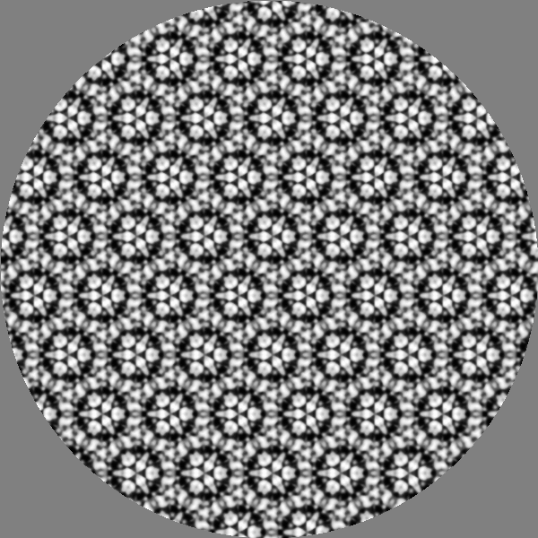

```r
knitr::include_graphics("img/P31M-2.png")
knitr::include_graphics("img/P31M-7.png")
```

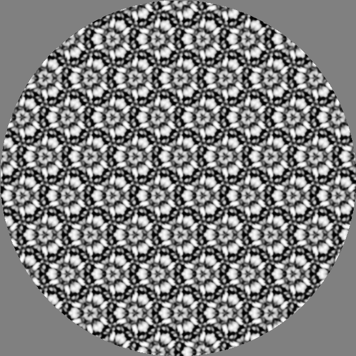

```r
knitr::include_graphics("img/P31M-2.png")
knitr::include_graphics("img/P31M-14.png")
```

```r
knitr::include_graphics("img/P31M-2.png")
knitr::include_graphics("img/P31M-20.png")
```

[output not shown]

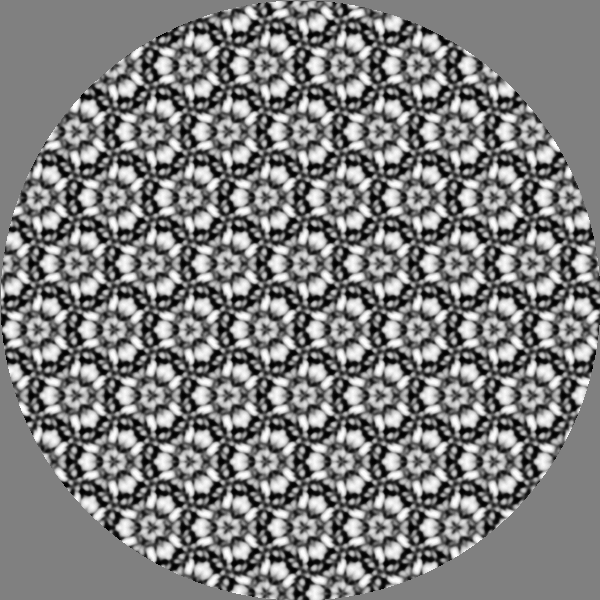

```r
knitr::include_graphics("img/P31M-14.png")
knitr::include_graphics("img/P31M-20.png")
```

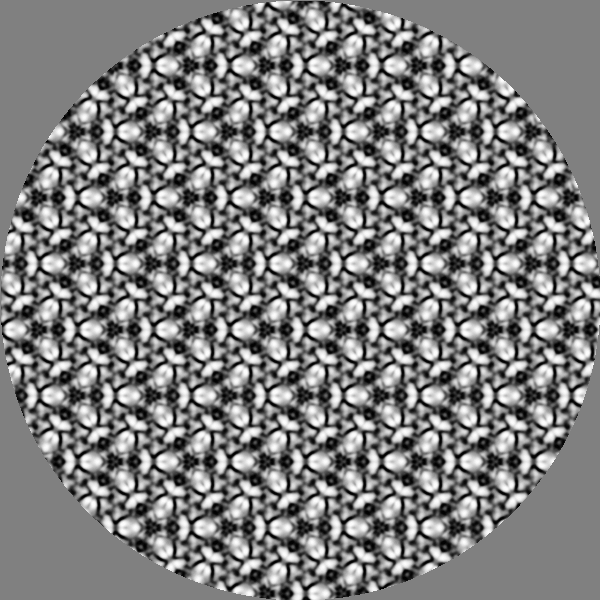

```r
knitr::include_graphics("img/P31M-19.png")
knitr::include_graphics("img/P31M-20.png")
```

#### P6

For P6, 2, 6, 9, 13, and 19 were rated highly self-similar.

[figure not shown]

[figure not shown]

```r
knitr::include_graphics("img/P6-6.png")
knitr::include_graphics("img/P6-13.png")
```

[figure not shown]

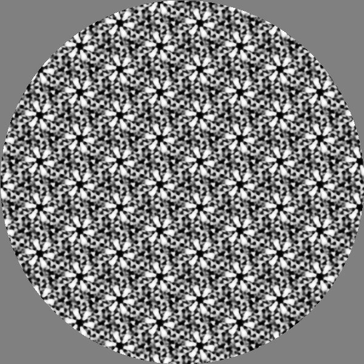

```r
knitr::include_graphics("img/P6-6.png")
knitr::include_graphics("img/P6-19.png")
```

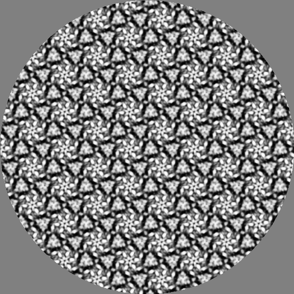

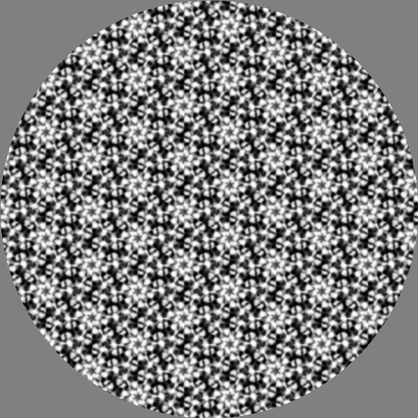

```r
knitr::include_graphics("img/P6-9.png")
knitr::include_graphics("img/P6-7.png")
```

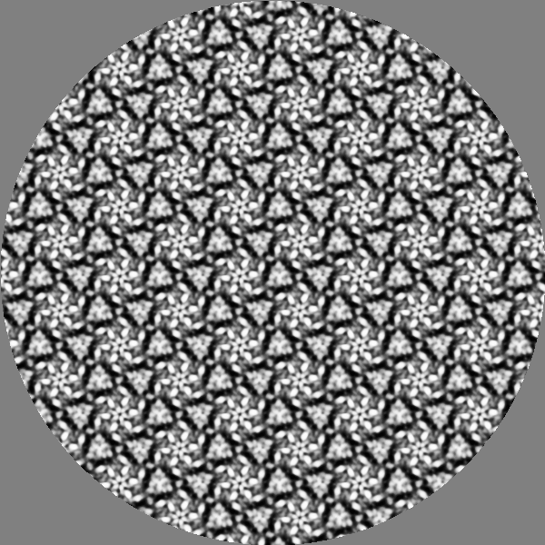

[figure not shown]

```r
knitr::include_graphics("img/P6-9.png")
knitr::include_graphics("img/P6-8.png")
```

## Analyses

```r
jaccard_mod1 <- aov(Jaccard ~ Group, jaccard)
summary(jaccard_mod1)
```

```
##              Df Sum Sq Mean Sq F value   Pr(>F)
## Group         4  0.490 0.12246   20.18 5.81e-16 ***
## Residuals   945  5.735 0.00607
## ---
## Signif. codes:
## 0 '***' 0.001 '**' 0.01 '*' 0.05 '.' 0.1 ' ' 1
```

```r
anova(jaccard_mod1)
```

```
## Analysis of Variance Table
##
## Response: Jaccard
##            Df Sum Sq  Mean Sq F value    Pr(>F)
## Group       4 0.4899 0.122465  20.178 5.809e-16 ***
## Residuals 945 5.7355 0.006069
## ---
## Signif. codes:
## 0 '***' 0.001 '**' 0.01 '*' 0.05 '.' 0.1 ' ' 1
```

Average Jaccard similarity scores differ across wallpaper groups, with mean scores for P1 the largest.

Nevertheless, there appear to be a number of exemplar pairs in other wallpaper groups that have especially high Jaccard scores. Let’s sort Jaccard indices across the wallpaper groups.

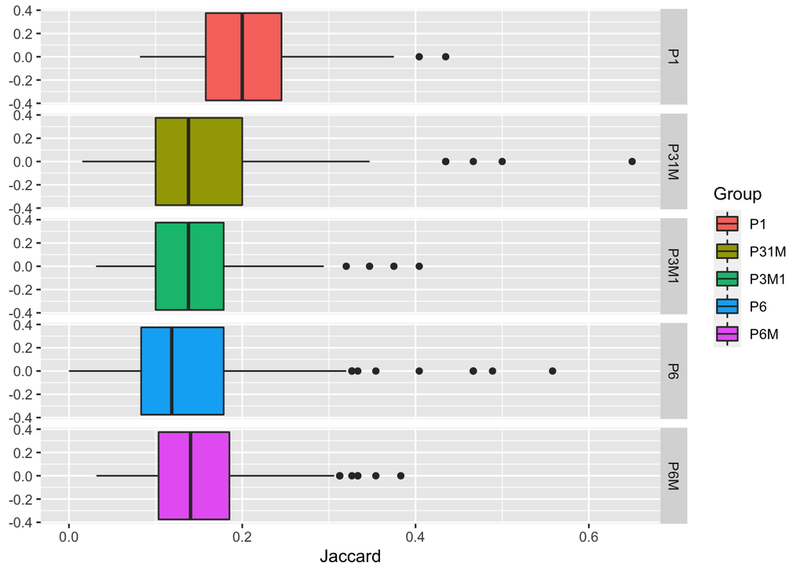

```r
jaccard_plot_2 <- jaccard %>%
  ggplot(.) +
  aes(x = Jaccard, fill = Group) +
  geom_boxplot() +
  facet_grid(Group ~ .)
jaccard_plot_2
```

```r
jaccard_sort <- jaccard %>%
  dplyr::arrange(., desc(Jaccard)) %>%
  dplyr::mutate(., overall_rank = 1:length(Jaccard))
```

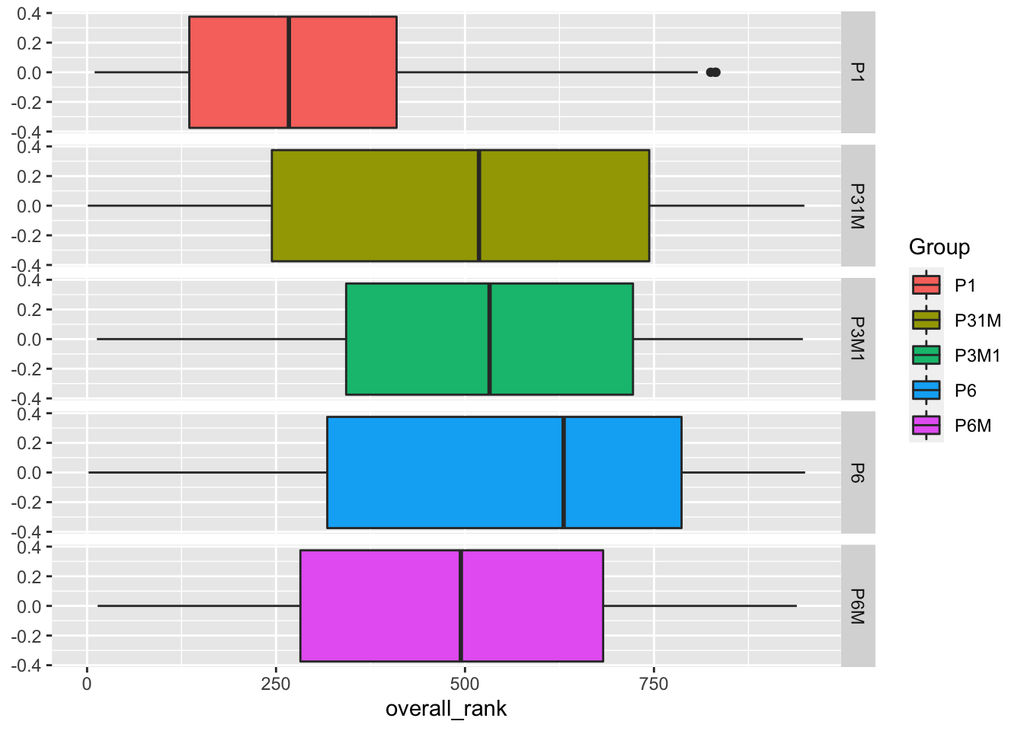

```r
jaccard_plot_3 <- jaccard_sort %>%
  ggplot(.) +
  aes(x = overall_rank, fill = Group) +
  geom_boxplot() +
  facet_grid(Group ~ .)
jaccard_plot_3
```

```r
jaccard_mod2 <- aov(overall_rank ~ Group, jaccard_sort)
summary(jaccard_mod2)
```

```
##              Df   Sum Sq Mean Sq F value Pr(>F)
## Group         4  8119014 2029753   30.29 <2e-16 ***
## Residuals   945 63328824   67015
## ---
## Signif. codes:
## 0 '***' 0.001 '**' 0.01 '*' 0.05 '.' 0.1 ' ' 1
```

```r
anova(jaccard_mod2)
```

```
## Analysis of Variance Table
##
## Response: overall_rank
##            Df   Sum Sq Mean Sq F value    Pr(>F)
## Group       4  8119014 2029753  30.288 < 2.2e-16 ***
## Residuals 945 63328824   67015
## ---
## Signif. codes:
## 0 '***' 0.001 '**' 0.01 '*' 0.05 '.' 0.1 ' ' 1
```

P1 still has the lowest mean rank.